# S_P_Timeseries

Vijay Mudivedu

6/6/2018

# Time Series Analysis of S&P 500

### Business Understandading

Business objective:

Please apply any machine learning algorithm you are comfortable with for predicting this time series

The results would be measured on:

1. Accuracy - How good are predictions
2. Visualization - How well are you able to convey your idea graphically
3. Code Cleanliness - How well have you documented your code in an easy language to understand. No need for excess code

Read Data from the CSV

```
## [1] 643  12
```

```
##   symbol   date_txn   open    low   high close_price    volume lead_1
## 1    SPY 11/10/2015 207.51 207.19 208.60      208.55  71844000 207.67
## 2    SPY 11/11/2015 208.88 207.66 208.94      207.67  67251000 204.84
## 3    SPY 11/12/2015 206.50 204.82 207.06      204.84 118209400 202.54
## 4    SPY 11/13/2015 204.35 202.44 204.67      202.54 145494400 205.62
## 5    SPY 11/16/2015 202.32 202.18 205.69      205.62 112996000 205.47
## 6    SPY 11/17/2015 205.99 204.88 207.04      205.47 113429400 208.73
##   lead_5 lead_10        name class_type_of
## 1 205.47  209.35 SPDR S&P500       S_P_500
## 2 208.73  209.32 SPDR S&P500       S_P_500
## 3 208.55  209.56 SPDR S&P500       S_P_500
## 4 209.31  208.69 SPDR S&P500       S_P_500
## 5 209.07  210.68 SPDR S&P500       S_P_500
## 6 209.35  208.53 SPDR S&P500       S_P_500
```

```
## 'data.frame':    643 obs. of  12 variables:
##  $ symbol       : Factor w/ 1 level "SPY": 1 1 1 1 1 1 1 1 1 1 ...
##  $ date_txn     : Factor w/ 643 levels "1/10/2017","1/10/2018",..: 106 109 111 112 118 121 124 126 129 135 ...
##  $ open         : num  208 209 206 204 202 ...
##  $ low          : num  207 208 205 202 202 ...
##  $ high         : num  209 209 207 205 206 ...
##  $ close_price  : num  209 208 205 203 206 ...
##  $ volume       : int  71844000 67251000 118209400 145494400 112996000 113429400 113064100 81363500 89556300 63829000 ...
##  $ lead_1       : num  208 205 203 206 205 ...
##  $ lead_5       : num  205 209 209 209 209 ...
##  $ lead_10      : num  209 209 210 209 211 ...
##  $ name         : Factor w/ 1 level "SPDR S&P500": 1 1 1 1 1 1 1 1 1 1 ...
##  $ class_type_of: Factor w/ 1 level "S_P_500": 1 1 1 1 1 1 1 1 1 1 ...
```

### Data Understanding

#### Data Preparation

- Remove Unwanted Columns

Remove the redundant columns symbol, name, class_type_of “SPY”, “SPDR S&P500”, “S_P_500”

```
##     date_txn   open    low   high close_price    volume lead_1 lead_5
## 1 11/10/2015 207.51 207.19 208.60      208.55  71844000 207.67 205.47
## 2 11/11/2015 208.88 207.66 208.94      207.67  67251000 204.84 208.73
## 3 11/12/2015 206.50 204.82 207.06      204.84 118209400 202.54 208.55
## 4 11/13/2015 204.35 202.44 204.67      202.54 145494400 205.62 209.31
## 5 11/16/2015 202.32 202.18 205.69      205.62 112996000 205.47 209.07
## 6 11/17/2015 205.99 204.88 207.04      205.47 113429400 208.73 209.35
##   lead_10
## 1  209.35
## 2  209.32
## 3  209.56
## 4  208.69
## 5  210.68
## 6  208.53
```

- Check for NAs

```
##    date_txn        open         low        high close_price      volume
##           0           0           0           0           0           0
##      lead_1      lead_5     lead_10
##           2           6          11
```

- Query to find NAs

```
## [1] 643   9
```

*Comments*: NAs were identified in lead_1, lead_5, lead_10

- NAs in Lead_1, Lead_5, Lead_10 are:

```
## $lead_1
## [1] 590 643
##
## $lead_5
## [1] 586 639 640 641 642 643
##
## $lead_10
##  [1] 581 634 635 636 637 638 639 640 641 642 643
```

- Remove NAs from lead_10

```
## [1] 632   9
```

- NAs in lead_1 and lead_5 are:

```
## $lead_1
## [1] 589
##
## $lead_5
## [1] 585
##
## $lead_10
## integer(0)
```

- Removing the NAs from lead_1 remaining the rows and columns are

```
## [1] 631   9
```

- NAs in Lead 5 are:

```
## $lead_1
## integer(0)
##
## $lead_5
## [1] 585
##
## $lead_10
## integer(0)
```

- Removing the NAs from lead_5, remaining the rows and columns are:

```
## [1] 630   9
```

```
##     date_txn   open    low   high close_price    volume lead_1 lead_5
## 1 11/10/2015 207.51 207.19 208.60      208.55  71844000 207.67 205.47
## 2 11/11/2015 208.88 207.66 208.94      207.67  67251000 204.84 208.73
## 3 11/12/2015 206.50 204.82 207.06      204.84 118209400 202.54 208.55
## 4 11/13/2015 204.35 202.44 204.67      202.54 145494400 205.62 209.31
## 5 11/16/2015 202.32 202.18 205.69      205.62 112996000 205.47 209.07
## 6 11/17/2015 205.99 204.88 207.04      205.47 113429400 208.73 209.35
##   lead_10
## 1  209.35
## 2  209.32
## 3  209.56
## 4  208.69
## 5  210.68
## 6  208.53
```

- check for outliers in close_price

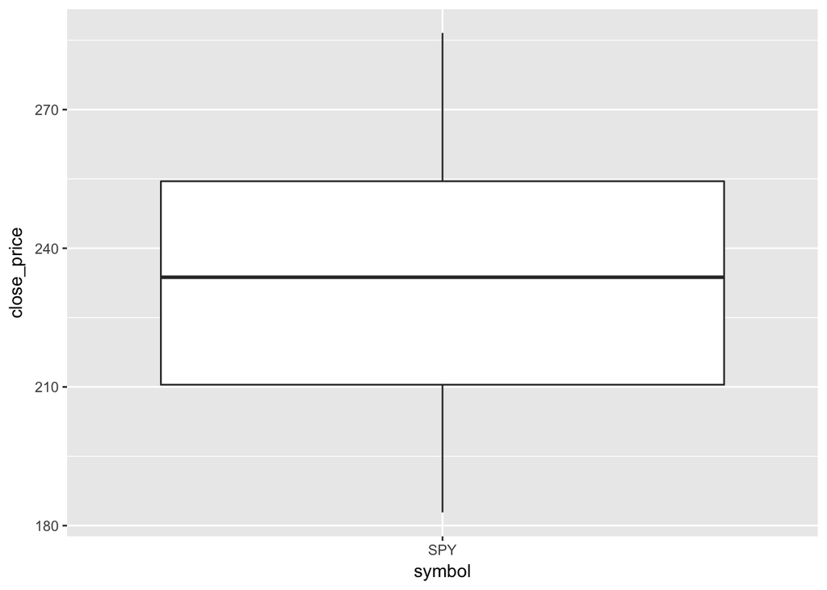

```
## [1] "2015-11-10" "2015-11-11" "2015-11-12" "2015-11-13" "2015-11-16"
## [6] "2015-11-17"
```

- Check for uniuqes and duplicates

```
## [1] 0
```

*Comments*: No duplicates found

- Check for invalid valid data - checking for minimum dips

```
##        open         low        high close_price      volume      lead_1
##         382         382         382          64         484          63
##      lead_5     lead_10
##         377          54
```

*Comments* : There is bad data in variables open, low, high, lead_1, thus considering the “close_price”

#### Exploratory Data Analyis

- Plotting the datasets

```
##    date_txn        open         low        high close_price      volume
##           0           0           0           0           0           0
##      lead_1      lead_5     lead_10
##           0           0           0
```

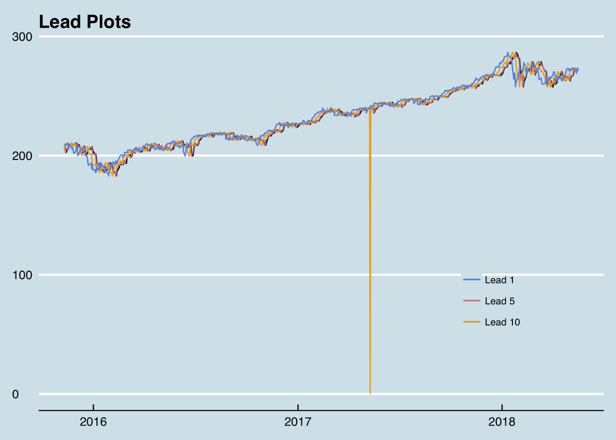

*Comments*: Thus considering the close_price as the lead_prices do not convey much information

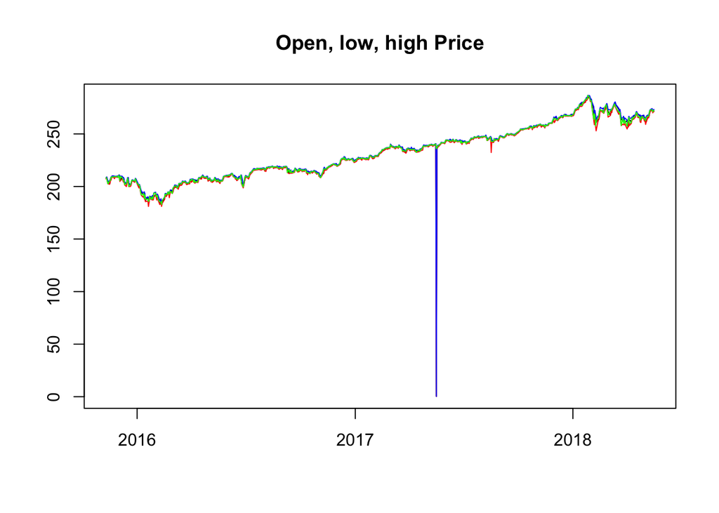

- Univariate analysis

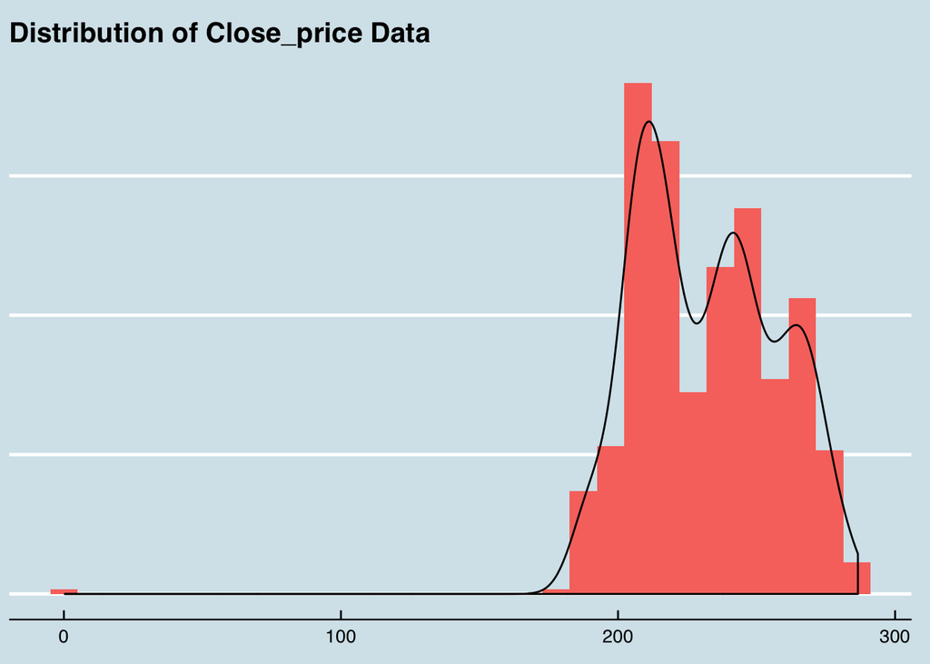

*Comments*: Most of the Pricing data is concentrated around 200 - 240

#### Time Series Object: Creating a time series object of “sp_historical_cleaned”

```
##              open    low   high close_price    volume lead_1 lead_5
## 2015-11-10 207.51 207.19 208.60      208.55  71844000 207.67 205.47
## 2015-11-11 208.88 207.66 208.94      207.67  67251000 204.84 208.73
## 2015-11-12 206.50 204.82 207.06      204.84 118209400 202.54 208.55
## 2015-11-13 204.35 202.44 204.67      202.54 145494400 205.62 209.31
## 2015-11-16 202.32 202.18 205.69      205.62 112996000 205.47 209.07
## 2015-11-17 205.99 204.88 207.04      205.47 113429400 208.73 209.35
##            lead_10
## 2015-11-10  209.35
## 2015-11-11  209.32
## 2015-11-12  209.56
## 2015-11-13  208.69
## 2015-11-16  210.68
## 2015-11-17  208.53
```

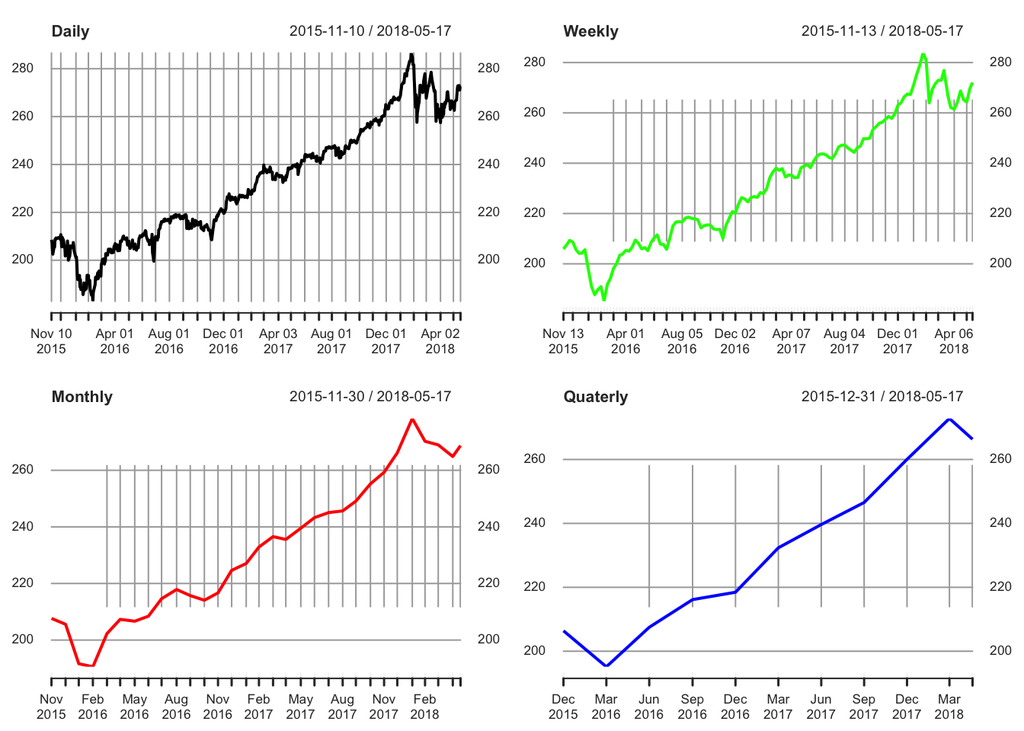

#### Training and Validation datasets

```
##       date_txn   open    low   high close_price    volume lead_1 lead_5
## 598 2018-03-28 260.75 258.58 262.64      259.83 146088900 263.15 265.64
## 599 2018-03-29 261.12 259.84 265.26      263.15 123162700 257.47 259.72
## 600 2018-04-02 262.55 254.67 263.13      257.47 184710400 260.77 261.00
## 601 2018-04-03 258.87 256.84 261.31      260.77 119492300 263.56 265.15
## 602 2018-04-04 256.75 256.60 264.36      263.56 123193700 265.64 263.76
## 603 2018-04-05 265.55 264.32 266.64      265.64  80980400 259.72 265.93
##     lead_10
## 598  265.93
## 599  265.15
## 600  267.33
## 601  270.19
## 602  270.39
## 603  268.89
```

```
##       date_txn   open    low   high close_price    volume lead_1 lead_5
## 604 2018-04-06 263.42 258.00 265.11      259.72 182029210 261.00 265.15
## 605 2018-04-09 261.37 259.94 264.84      261.00 104745500 265.15 267.33
## 606 2018-04-10 264.27 262.98 266.04      265.15 104375800 263.76 270.19
## 607 2018-04-11 263.47 263.39 265.64      263.76  90886300 265.93 270.39
## 608 2018-04-12 265.26 265.06 267.00      265.93  68138500 265.15 268.89
## 609 2018-04-13 267.41 264.01 267.54      265.15  84647281 267.33 266.61
##     lead_10
## 604  266.61
## 605  266.57
## 606  262.98
## 607  263.63
## 608  266.31
## 609  266.56
```

```
## [1] 600   9
```

```
## [1] 30  9
```

### Smoothing

#### Smoothing using Classical Decomposition

- window width

```
## [1] 9
```

- Printing the smooted moving average:

```
## Time Series:
## Start = 1
## End = 20
## Frequency = 1
##  [1]       NA       NA       NA       NA       NA       NA       NA
##  [8]       NA       NA 207.8979 207.8137 207.6911 207.7453 207.7058
## [15] 207.5626 207.5395 207.5026 207.3084 206.8195 206.4300
```

- Replacing the induced NAs as result of smoothing

```
## [1] -0.08421053
```

```
## [1] 0.2178947
```

- Replacing the lagging NAs are a result of windowing of moving average

```
## Time Series:
## Start = 1
## End = 20
## Frequency = 1
##  [1] 208.6558 208.5716 208.4874 208.4032 208.3189 208.2347 208.1505
##  [8] 208.0663 207.9821 207.8979 207.8137 207.6911 207.7453 207.7058
## [15] 207.5626 207.5395 207.5026 207.3084 206.8195 206.4300
```

- Replacing the smoothed leading NAs

```
## Time Series:
## Start = 581
## End = 600
## Frequency = 1
##  [1] 272.9321 272.4353 271.7326 271.4726 270.9568 270.1737 269.3974
##  [8] 268.5047 267.9321 268.1500 268.3679 268.5858 268.8037 269.0216
## [15] 269.2395 269.4574 269.6753 269.8932 270.1111 270.3289
```

- Plotting the Smoothed Close Price

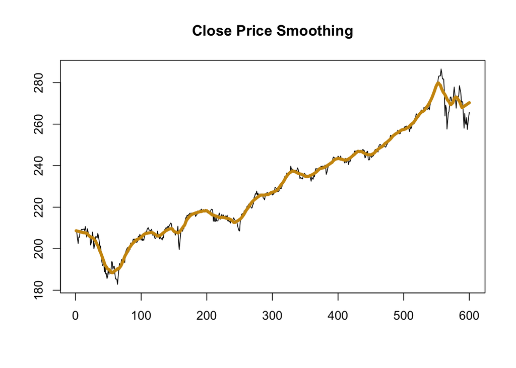

#### Smoothing using Holts method

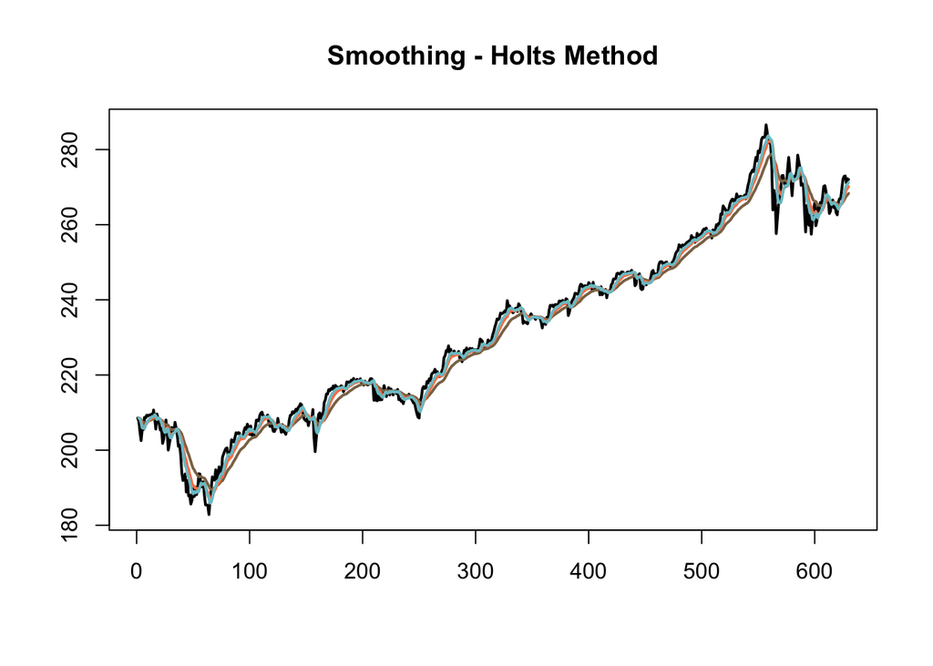

*Comments*: Clearly, from Holts Method best smoothing happens when alpha is ~ 0.1

- Holts smoothed series Plot

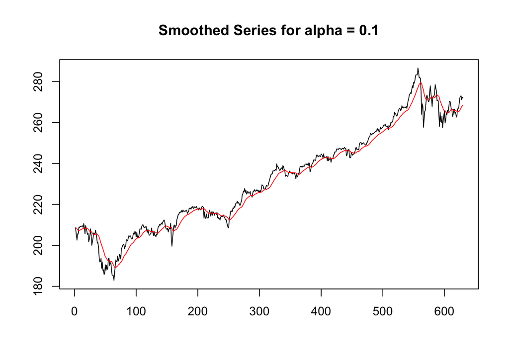

- Creating a new dat frame for close_price and dates

```
##   months_smoothed smoothed_close_price
## 1               1             208.6558
## 2               2             208.5716
## 3               3             208.4874
## 4               4             208.4032
## 5               5             208.3189
## 6               6             208.2347
```

### Model Building

```
##
## Call:
## lm(formula = smoothed_close_price ~ cos(0.05 * months_smoothed) *
##     poly(months_smoothed, 1) + sin(0.05 * months_smoothed) *
##     poly(months_smoothed, 1), data = smoothed_df)
##
## Residuals:
##      Min       1Q   Median       3Q      Max
## -10.3422  -4.0300  -0.1904   3.7777  12.2405
##
## Coefficients:
##                                                       Estimate Std. Error
## (Intercept)                                          230.23069    0.19667
## cos(0.05 * months_smoothed)                           -0.02158    0.27776
## poly(months_smoothed, 1)                             567.96883    4.87636
## sin(0.05 * months_smoothed)                            1.85678    0.27629
## cos(0.05 * months_smoothed):poly(months_smoothed, 1) -88.38120    6.92574
## poly(months_smoothed, 1):sin(0.05 * months_smoothed)   6.63155    6.78174
##                                                       t value Pr(>|t|)
## (Intercept)                                          1170.650  < 2e-16 ***
## cos(0.05 * months_smoothed)                            -0.078    0.938
## poly(months_smoothed, 1)                              116.474  < 2e-16 ***
## sin(0.05 * months_smoothed)                             6.720 4.25e-11 ***
## cos(0.05 * months_smoothed):poly(months_smoothed, 1)  -12.761  < 2e-16 ***
## poly(months_smoothed, 1):sin(0.05 * months_smoothed)    0.978    0.329
## ---
## Signif. codes:  0 '***' 0.001 '**' 0.01 '*' 0.05 '.' 0.1 ' ' 1
##
## Residual standard error: 4.77 on 594 degrees of freedom
## Multiple R-squared:  0.961,  Adjusted R-squared:  0.9606
## F-statistic:  2925 on 5 and 594 DF,  p-value: < 2.2e-16
```

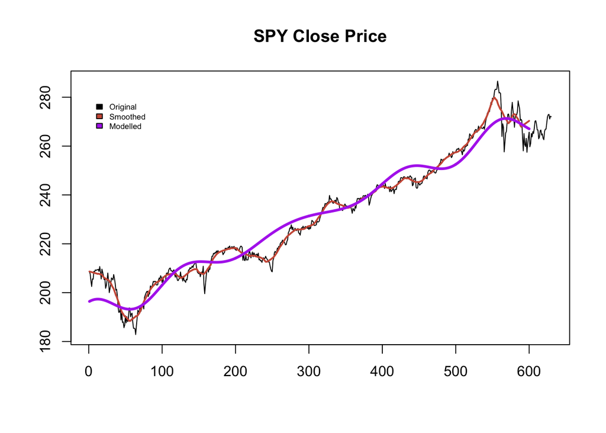

- Stationarity tests on the residual time series:

```
##         1         2         3         4         5         6
## 12.134755 11.095516  8.121673  5.693146  8.659823  8.411551
```

- adf test and kpss test for stationarity:

```
##
##  Augmented Dickey-Fuller Test
##
## data:  resi_close_price
## Dickey-Fuller = -4.0685, Lag order = 8, p-value = 0.01
## alternative hypothesis: stationary
```

```
##
##  KPSS Test for Level Stationarity
##
## data:  resi_close_price
## KPSS Level = 0.6319, Truncation lag parameter = 5, p-value =
## 0.01974
```

- ACF and PACF Plots are:

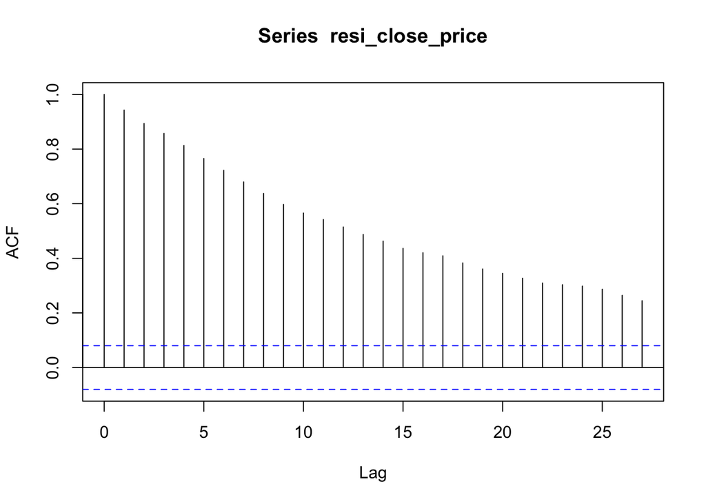

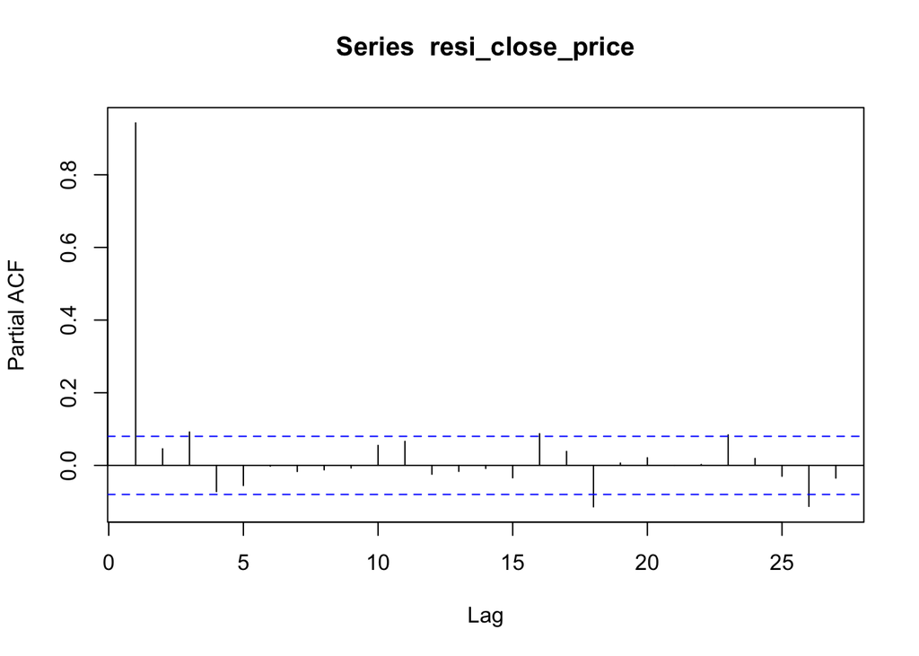

```
## Series: resi_close_price
## ARIMA(0,0,0) with non-zero mean
##
## Coefficients:
##          mean
##       -0.0961
## s.e.   0.2227
##
## sigma^2 estimated as 29.81:  log likelihood=-1869.27
## AIC=3742.55   AICc=3742.57   BIC=3751.34
```

- checking the noise and stationarity of the time series using the box-Ljung test

```
##
##  Box-Ljung test
##
## data:  resi_close_price
## X-squared = 535.84, df = 1, p-value < 2.2e-16
```

- QQPlot of the residual timeseries

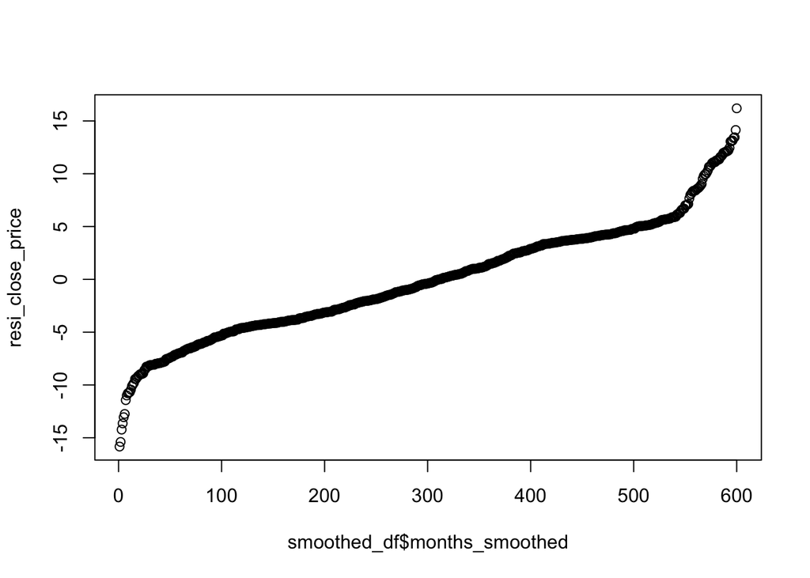

- Plotting the histogram of the residual time-series represents a Gaussian Curve

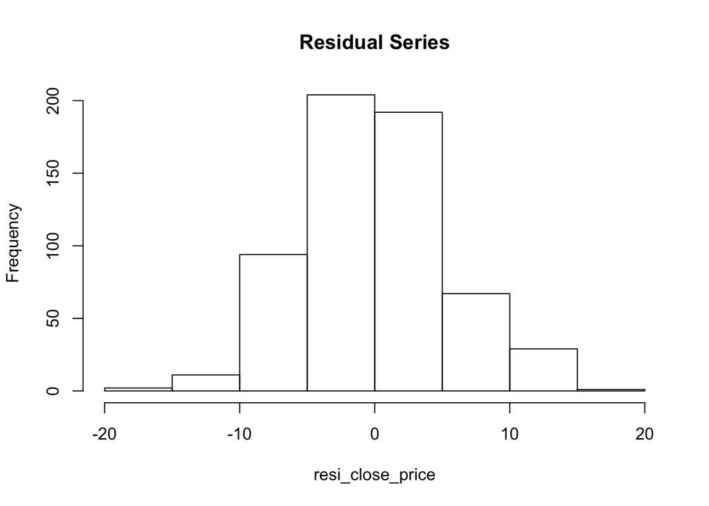

- Checking the properities of Residual time-series by inspection

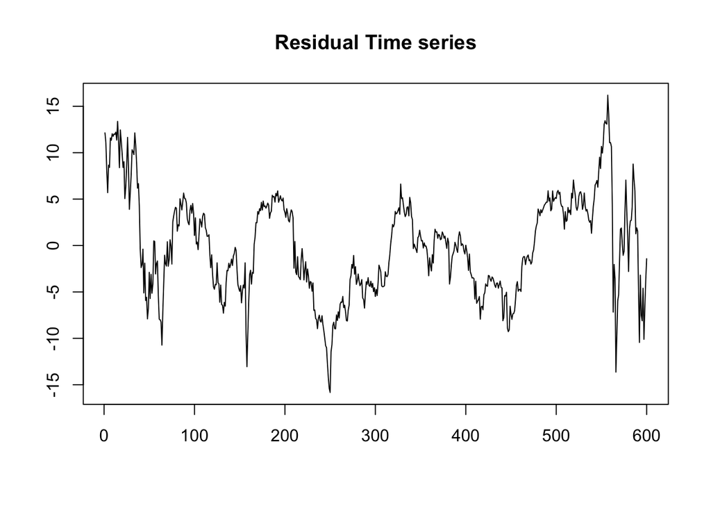

### Model Evaluation

- Predicting the values fitted model from the vadlidation dataset

```
##   months_smoothed
## 1             601
## 2             602
## 3             603
## 4             604
## 5             605
## 6             606
```

- MAPE Error - Accuracy Calculation

```
## [1] 1.026822
```

*Comments*: Thus with a MAPE error of just 1.0268, model is apparently a very good fit.

- Combining the predicted values train and test data
- Plottig the actual vs the predicted data, using classical decomposition

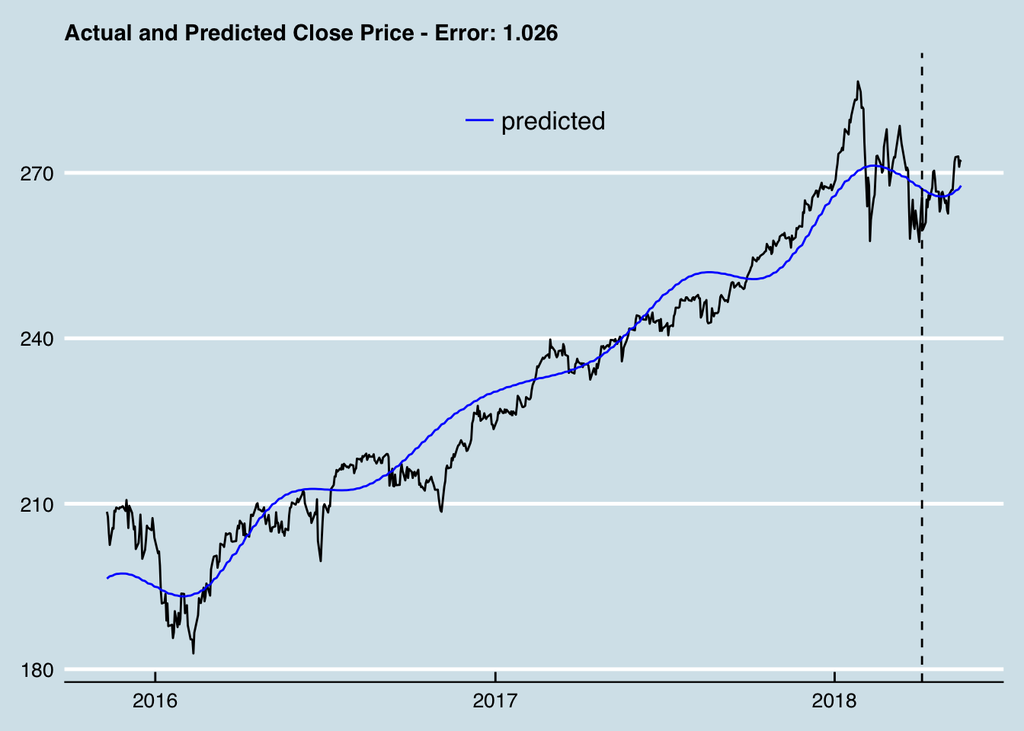

### PREDICTION ANALYSIS USING AUTO.ARIMA

#### Modelling auto arima

```
## Series: sp_train$close_price
## ARIMA(4,1,0)
##
## Coefficients:
##           ar1      ar2     ar3     ar4
##       -0.0655  -0.0858  0.0847  0.0362
## s.e.   0.0409   0.0410  0.0411  0.0416
##
## sigma^2 estimated as 3.148:  log likelihood=-1191.36
## AIC=2392.73   AICc=2392.83   BIC=2414.7
##
## Training set error measures:
##                      ME     RMSE      MAE        MPE      MAPE     MASE
## Training set 0.09879535 1.766713 1.188871 0.03878482 0.5244785 0.999416
##                      ACF1
## Training set -0.002495871
```

- Predicting the Validation dataset

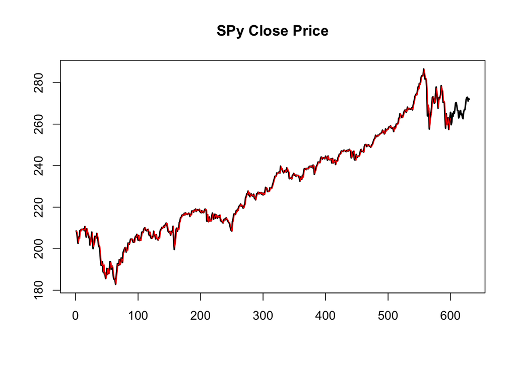

- MAPE of Close Price Using Auto Arima.

```
## [1] 1.079454
```

- Combining the predicted training and testing to plot
- Combined plot of Arima

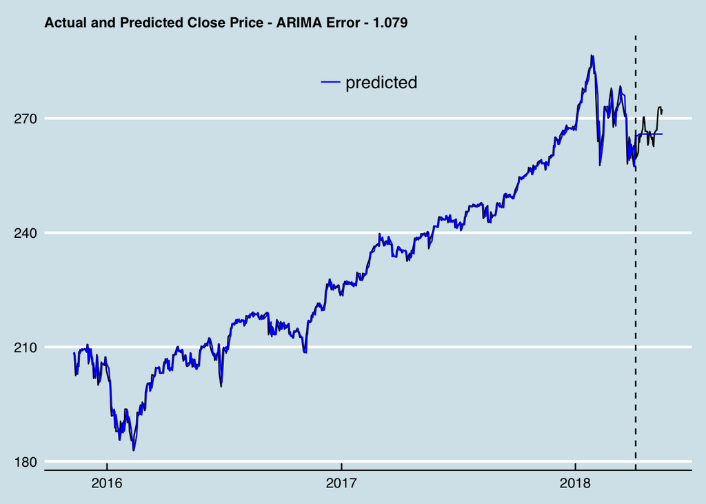

### Conclusion

- Thus the Accuracy result using the MAPE using Classicial Decomposition is 1.03 which is less than Auto.Arima Modelling 1.08 and Classical Decompsition has had higher accuracy*